# report_exercise_2

Reto Moser

2023-13-03

In this exercise, I will work with the dataset airquality with information about air quality measurements in New York from May to September 1973.I loaded the dataset and the nececarry lybraries for this task.

### Prepear Data

For every plot I tydied and saved the variables I need first. It is easier to plot the data when the date is represented as a single variable instead of separate variables for the month and day. Using the “as.Date” command, I can create a Year-Month-Day variable by combining the monthly and day variables. In the dataset, there are already some missing values, as seen in the first few rows. To create the plots, I have decided to remove these missing values using the na.omit() function.

## Figures

### Line Plot with ozone levels over time

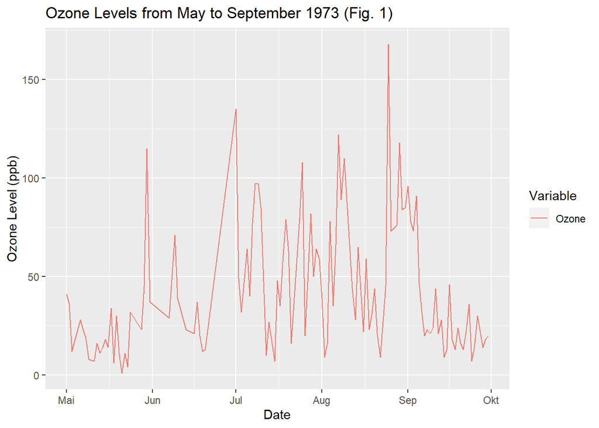

```r
aqny_ozone <- aqny %>% select(Month, Day, Ozone)
aqny_ozone$Date <- as.Date(paste("1973", aqny_ozone$Month, aqny_ozone$Day, sep = "-"))

aqny_ozone <- select(aqny_ozone, -Month, -Day)
aqny_ozone <- na.omit(aqny_ozone)

ozone <- gather(aqny_ozone, key = "Variable", value = "Value", -Date)

ggplot(ozone, aes(x = Date, y = Value, color = Variable)) +
geom_line() +
labs(title = "Ozone Levels from May to September 1973 (Fig. 1)", x = "Date", y = "Ozone Level (ppb)")
```

### Barplot with Temperature Daily

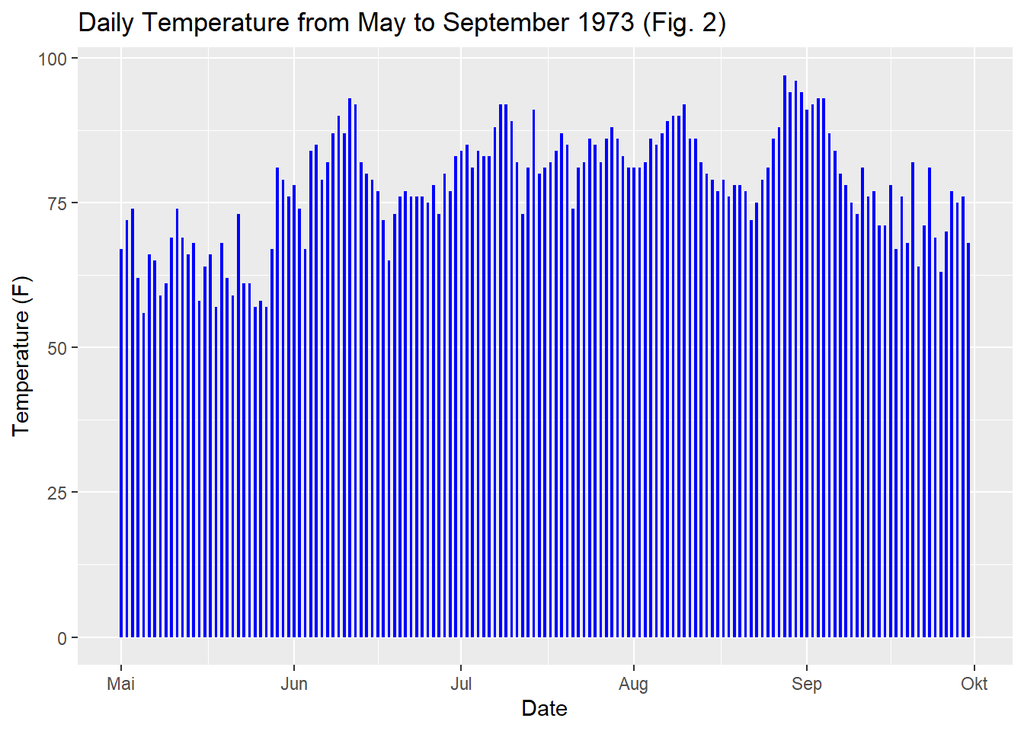

```r
aqny_daily <- aqny %>%
  mutate(Date = as.Date(paste(1973, Month, Day, sep = "-"), "%Y-%m-%d")) %>%
  select(Date, Temp) %>%
  na.omit()

ggplot(aqny_daily, aes(x = Date, y = Temp)) +
  geom_bar(stat = "identity", fill = "blue", width = 0.5) +
  labs(title = "Daily Temperature from May to September 1973 (Fig. 2)", x = "Date", y = "Temperature (F)")
```

### Scatter Plot Temperature vs Ozone levels

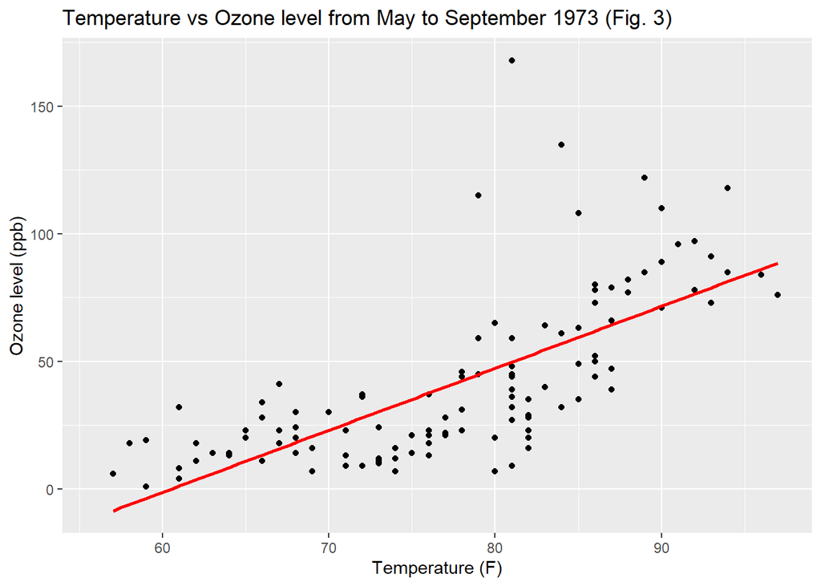

```r
ggplot(data = aqny, aes(x = Temp, y = Ozone)) +
  geom_point() +
  geom_smooth(method = lm, se = FALSE, col = "red") +
  xlab("Temperature (F)") +
  ylab("Ozone level (ppb)") +
  ggtitle("Temperature vs Ozone level from May to September 1973 (Fig. 3)")
```

### Scatterplot of Ozone vs. Solar Radiation

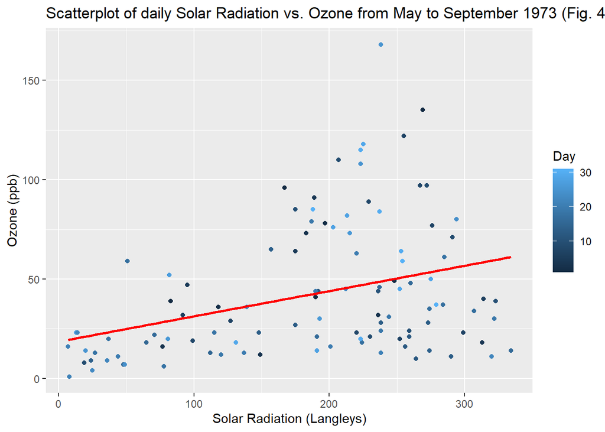

```r
ggplot(data = aqny, aes(x = Solar.R, y = Ozone, color = Day)) +
  geom_point() +
  geom_smooth(method = lm, se = FALSE, col = "red") +
  xlab("Solar Radiation (Langleys)") +
  ylab("Ozone (ppb)") +
  ggtitle("Scatterplot of daily Solar Radiation vs. Ozone from May to September 1973 (Fig. 4)")
```

##Statistical Metrics

### Mean of Ozone for each month

```r
ozone_monthly <- aqny %>%
  mutate(month = as.Date(paste(1973, Month, "1", sep = "-"), "%Y-%m-%d")) %>%
  group_by(month = lubridate::floor_date(month, unit = "month")) %>%
  summarise(mean_ozone = mean(Ozone, na.rm = TRUE))

print(ozone_monthly)
```

```
## # A tibble: 5 × 2
##   month      mean_ozone
##   <date>          <dbl>
## 1 1973-05-01       23.6
## 2 1973-06-01       29.4
## 3 1973-07-01       59.1
## 4 1973-08-01       60.0
## 5 1973-09-01       31.4
```

This mean can be used to determine if the Ozone levels are increased or harmful to human life.

### Correlations between the variables

With the command cor(), I can calculate this value, which can range from -1 to +1. The negative values being negative correlations, and the postivie values positive correlations. If the correlation is positiv, that means if one Input increases, the other increases as well.

```r
aqny_correlation <- na.omit(aqny)

correlation <- cor(aqny_correlation[, c("Ozone", "Solar.R", "Wind", "Temp")])
print(correlation)
```

```
##              Ozone    Solar.R       Wind       Temp
## Ozone    1.0000000  0.3483417 -0.6124966  0.6985414
## Solar.R  0.3483417  1.0000000 -0.1271835  0.2940876
## Wind    -0.6124966 -0.1271835  1.0000000 -0.4971897
## Temp     0.6985414  0.2940876 -0.4971897  1.0000000
```

Correlations: - Ozone/Solar.R = 0.35, positive correlation. - Ozone/Wind = -0.61, negative correlation. - Ozone/Temp = 0.70 strong positive correlation. - Solar.R = -0.12 weak negative correlation. - Solar.R/Temp = 0.29 positive correlation. - Wind/Temp = -0.50

### Percentiles of Temperature

```r
temp_percent <- quantile(aqny$Temp, c(0.25, 0.5, 0.75), na.rm = TRUE)

print(paste("Temperature Percentiles:", temp_percent))
```

```
## [1] "Temperature Percentiles: 72" "Temperature Percentiles: 79"
## [3] "Temperature Percentiles: 85"
```

## Discussion

Analyzing temperatures from May-September, we calculate the 25th, 50th, and 75th percentiles, resulting in values of 72, 79, and 85, respectively. Generally, temperatures are high, with the top 25% reaching above 85°F. Fig.2 demonstrates that June, July, and August are the warmest months. A hypothesis suggests a correlation between ozone and temperature, which is visualized in Fig.3, indicating a correlation between these variables.

According to the WHO guidelines, ozone formation is a result of gas reactions with sunlight, implying that temperature might be an outcome of increased solar radiation rather than directly influencing heightened ozone levels (World Health Organization: WHO). Fig.4 displays the correlation between ozone and solar radiation, further suggesting a correlation.

Interestingly, there is a strong negative correlation between ozone levels and wind speed. Investigating this further could reveal insights into rainy/stormy days with significant wind and no ozone production, or sunny days with high wind dispersing the formed ozone across urban and rural areas. Exploring this correlation could be a potential avenue for further examination of air quality.

### Literature:

World Health Organization: WHO. “Ambient (Outdoor) Air Pollution.” www.who.int, Dec. 2022, www.who.int/news-room/fact-sheets/detail/ambient-(outdoor)-air-quality-and-health.